# Supplemental code for Goodness of fit for log-linear ERGMs

Submitted to JCGS 2023-2024

Authors anonymized during review process

# Prerequisites

```
library("igraph")
```

Load the necessary functions we wrote for testing GoF:

```r
# set your working directory to something else if running this on the server and not in the dropbox:
#setwd("~/GoF/Code/")
# in this file I am using "myFolderName" for storing the simulation files.

# get the required functions:
# download the following 3 files from the submission supplement:
source('basicWalk.R')
source('histogramsForWalks.R')
source('Test.Model.Fit.R')
```

# Test Model Fit Examples

Here is one small graph on 10 nodes:

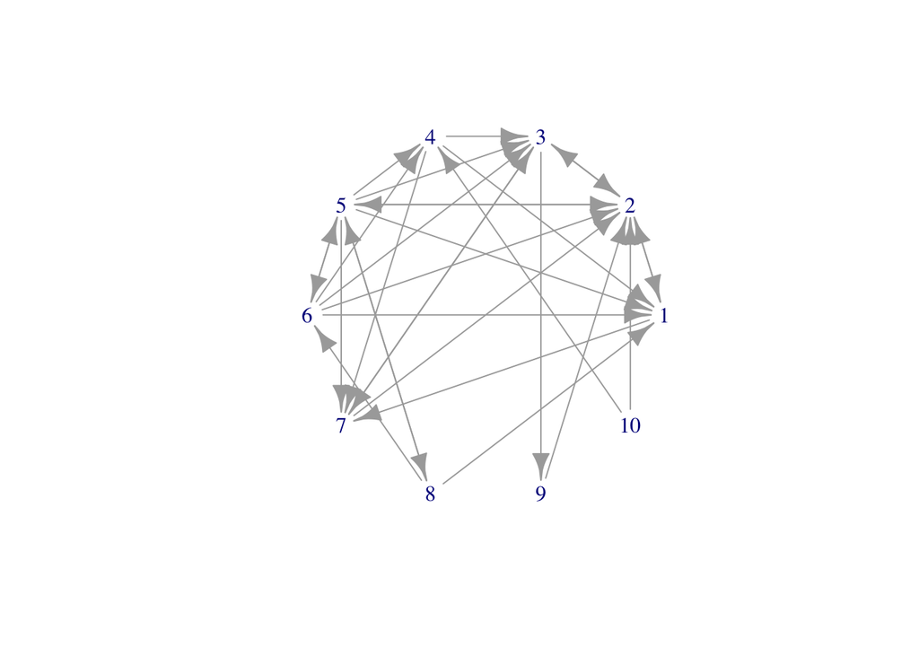

```r
D.HL2 = graph(c(1,2,1,7,2,1,2,3,2,5,3,2,3,7,3,9,4,1,4,3,4,7,5,1,5,2,5,3,5,4,5,6,5,7,5,8,6,1,6,2,6,3,6,4,6,5,7,2,7,3,8,1,8,5,8,6,9,2,10,2,10,4))
plot(D.HL2,layout=layout.circle,vertex.shape="none")
```

```r
iters = 3
steps = 2000
mle = Get.MLE(D.HL2, model="p1.recip.zero", tol=0.01, maxiter=10000)
HL2.no.trivial.moves = Test.Model.Fit(gdir=D.HL2, foldername=myFolderName, numSteps=steps, iterations=iters, model="p1.recip.nzconst", ignore.trivial.moves=TRUE, mleMatr=mle, testname="HL2")
```

```
## iteration = 1
## [1] "Estimate.p.Value.for.Testing log: Employing user-provided MLE."
## p.values[1] = 0.774194
```

```
## mean(p.values[1:1]) = 0.774194 | median(p.values[1:1]) = 0.774194 | var(p.values[1:1]) = NA
## iteration = 2
## [1] "Estimate.p.Value.for.Testing log: Employing user-provided MLE."
## p.values[2] = 0.500000
```

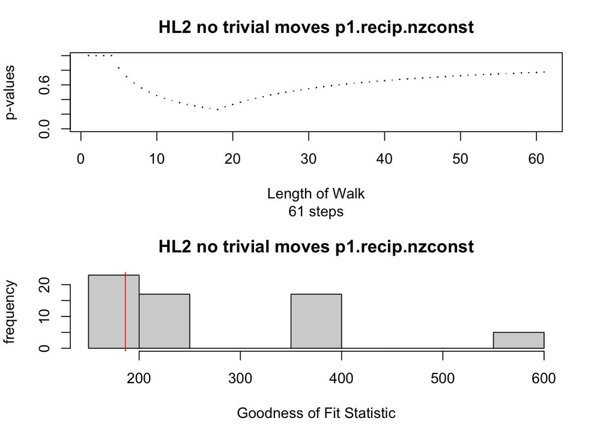

```
## mean(p.values[1:2]) = 0.637097 | median(p.values[1:2]) = 0.637097 | var(p.values[1:2]) = 0.037591
## iteration = 3
## [1] "Estimate.p.Value.for.Testing log: Employing user-provided MLE."
## p.values[3] = 0.352113
```

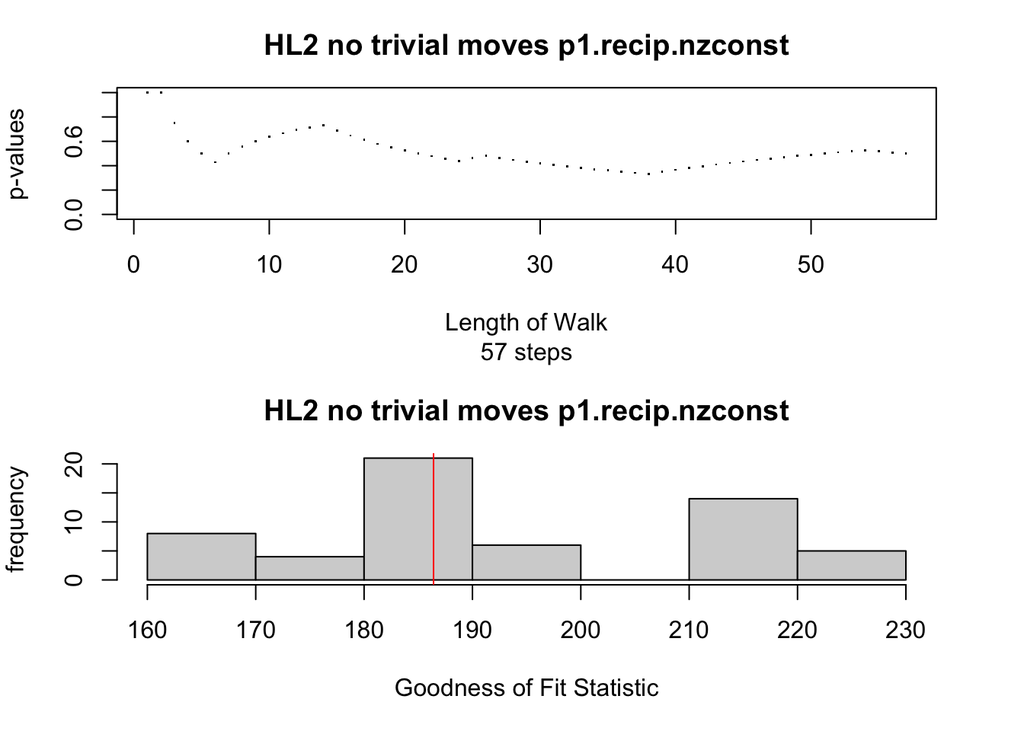

```
## mean(p.values[1:3]) = 0.542102 | median(p.values[1:3]) = 0.500000 | var(p.values[1:3]) = 0.045868
```

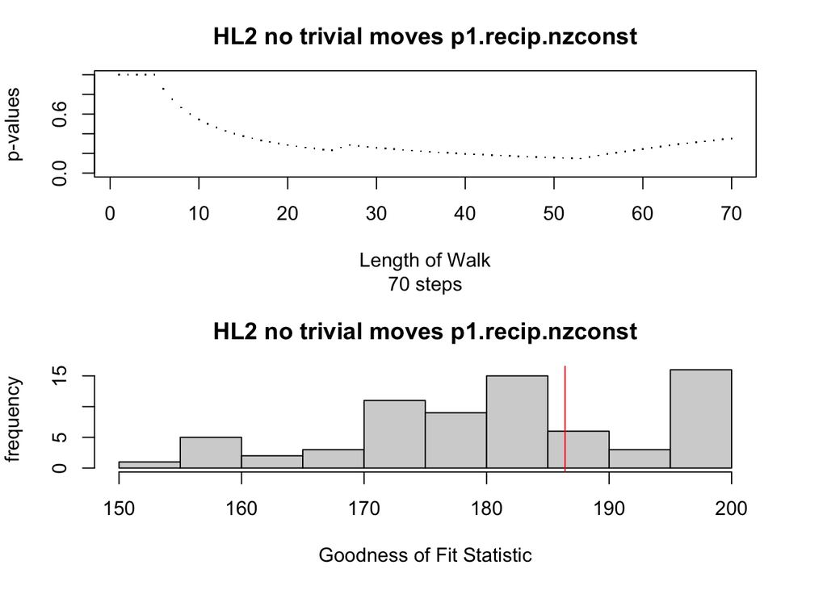

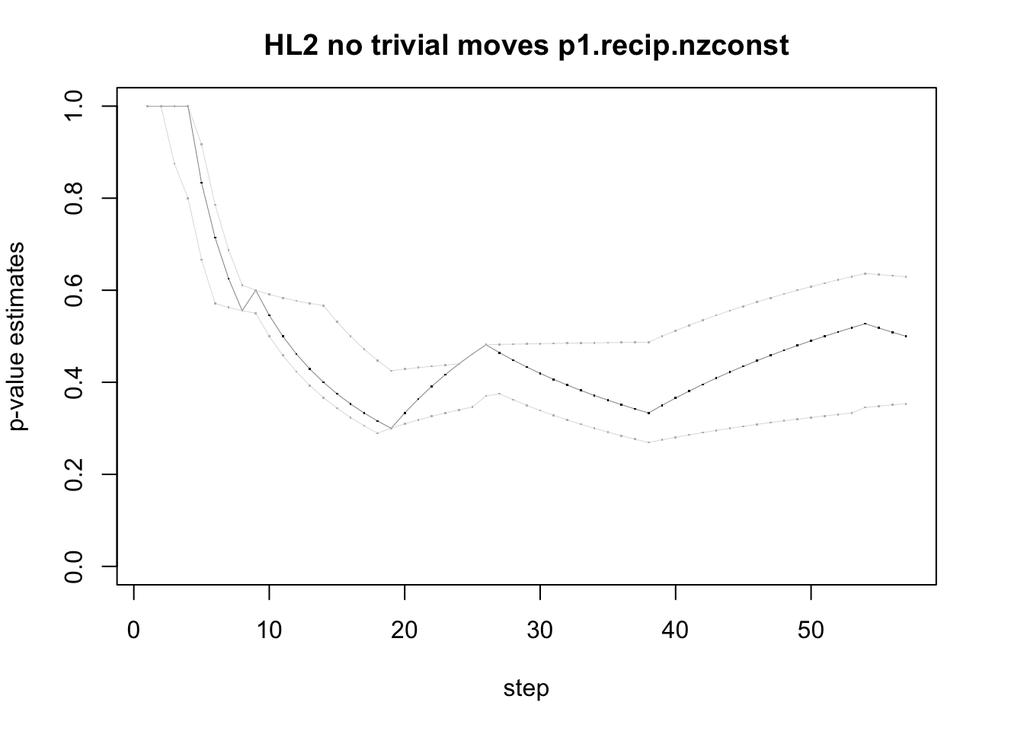

We can repeat the same test but keep the number of samples to 2000, regardless of rejected proposed steps the chain might encounter:

```r
HL2.with.trivial.moves = Test.Model.Fit(gdir=D.HL2, foldername=myFolderName, numSteps=steps, iterations=iters, model="p1.recip.nzconst", mleMatr=mle, testname="HL2")
```

```
## iteration = 1
## [1] "Estimate.p.Value.for.Testing log: Employing user-provided MLE."
## p.values[1] = 0.582209
```

```
## mean(p.values[1:1]) = 0.582209 | median(p.values[1:1]) = 0.582209 | var(p.values[1:1]) = NA
## iteration = 2
## [1] "Estimate.p.Value.for.Testing log: Employing user-provided MLE."
## p.values[2] = 0.808596
```

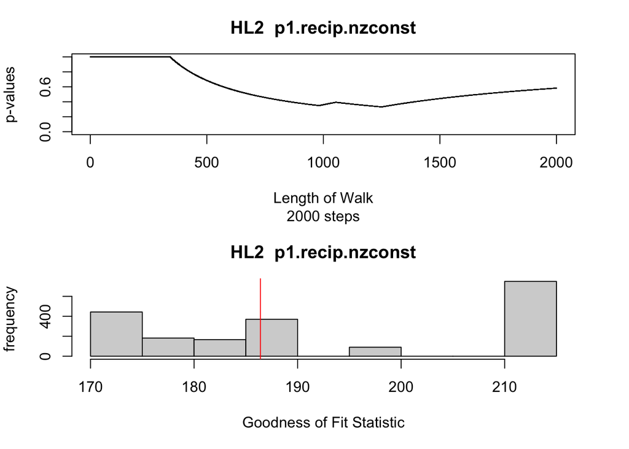

```
## mean(p.values[1:2]) = 0.695402 | median(p.values[1:2]) = 0.695402 | var(p.values[1:2]) = 0.025625
## iteration = 3
## [1] "Estimate.p.Value.for.Testing log: Employing user-provided MLE."
## p.values[3] = 0.786607
```

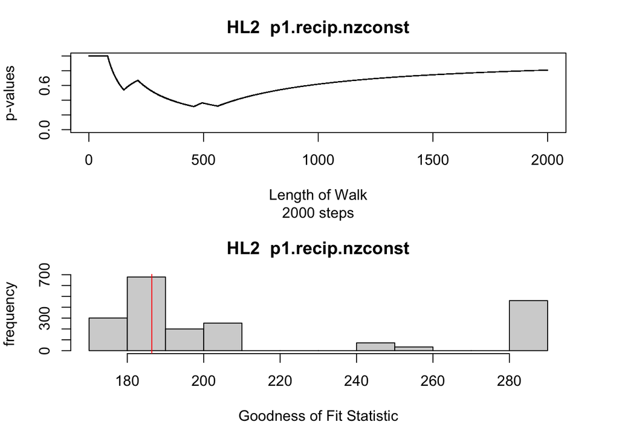

```
## mean(p.values[1:3]) = 0.725804 | median(p.values[1:3]) = 0.786607 | var(p.values[1:3]) = 0.015585
```

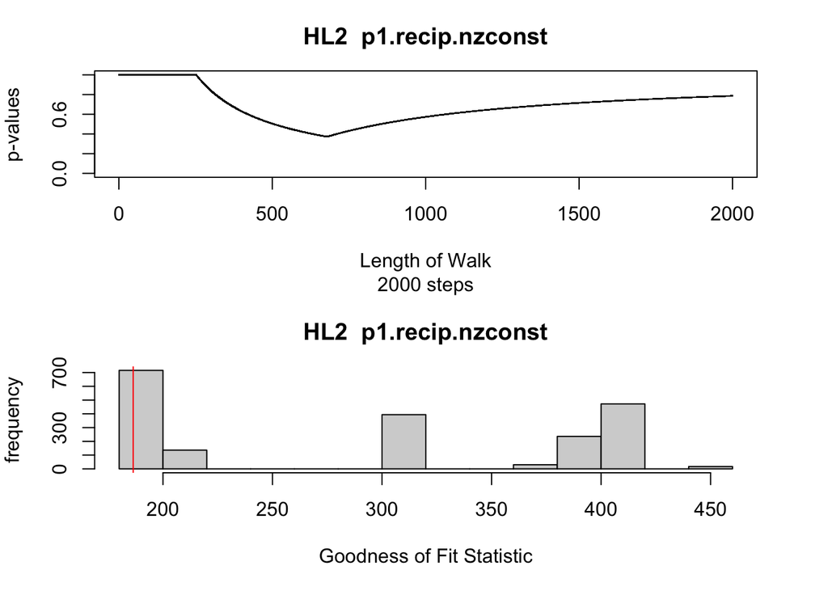

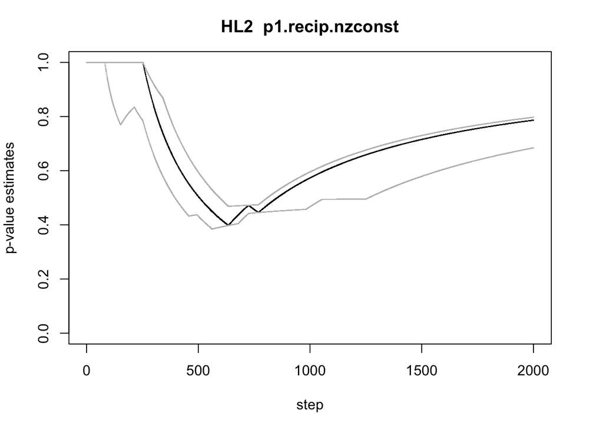

## Small example for the beta-SBM model

This is the exponential family version of the degree-corrected SBM, where the block membership is *known* a priori.

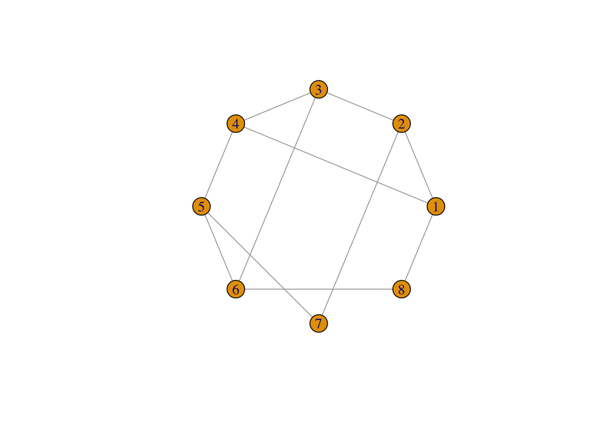

```r
########################################################################################################################################################################
########################################################################################################################################################################
# beta SBM model Example
g = graph(c(1,2,2,3,3,4,4,1, 5,6,7,5,6,8, 4,5,3,6,2,7,1,8), d=FALSE)
plot(g, layout= layout.circle)
```

```r
my.blocks = c(1, 1, 1, 1, 2, 2, 2, 2)

iters = 3
steps = 20000 # I am setting steps to a lower value for illustration purposes. The knitted file used steps=20000.
mle.b.SBM = Get.MLE(g, model="beta.SBM", tol=0.01, maxiter=10000, SBM.blocks = my.blocks)
test.b.SBM.with.trivial.moves = Test.Model.Fit(g, foldername=myFolderName, numSteps=steps, iterations=iters, model="beta.SBM", mleMatr=mle.b.SBM, testname="betaSBM",SBM.blocks = my.blocks)
```

```
## iteration = 1
## [1] "Estimate.p.Value.for.Testing log: Employing user-provided MLE."
## p.values[1] = 0.553772
```

```
## mean(p.values[1:1]) = 0.553772 | median(p.values[1:1]) = 0.553772 | var(p.values[1:1]) = NA
## iteration = 2
## [1] "Estimate.p.Value.for.Testing log: Employing user-provided MLE."
## p.values[2] = 0.587271
```

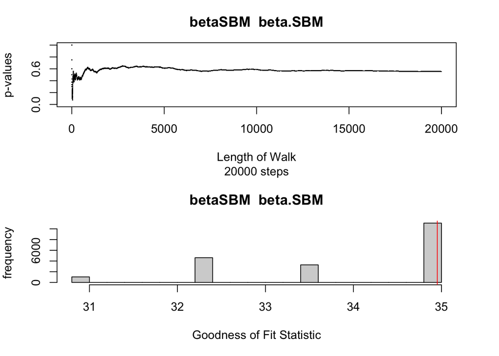

```
## mean(p.values[1:2]) = 0.570521 | median(p.values[1:2]) = 0.570521 | var(p.values[1:2]) = 0.000561
## iteration = 3
## [1] "Estimate.p.Value.for.Testing log: Employing user-provided MLE."
## p.values[3] = 0.579021
```

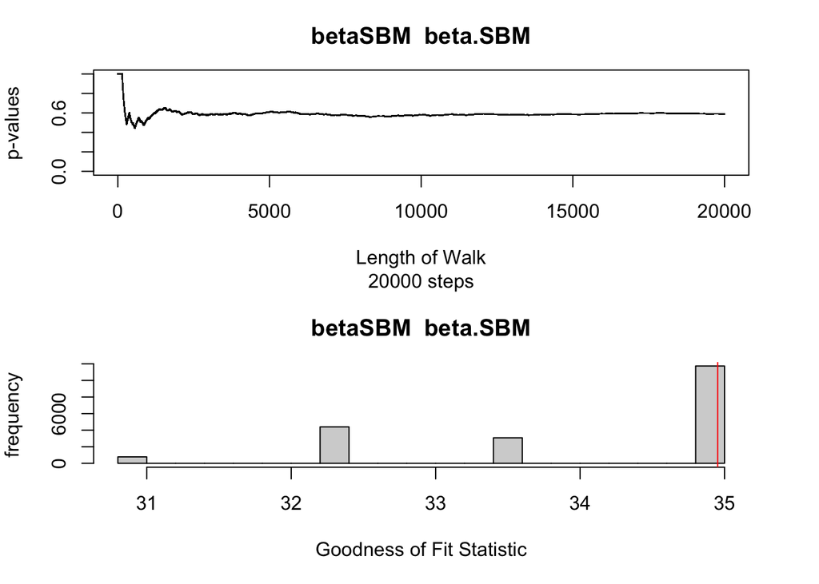

```
## mean(p.values[1:3]) = 0.573355 | median(p.values[1:3]) = 0.579021 | var(p.values[1:3]) = 0.000305
```

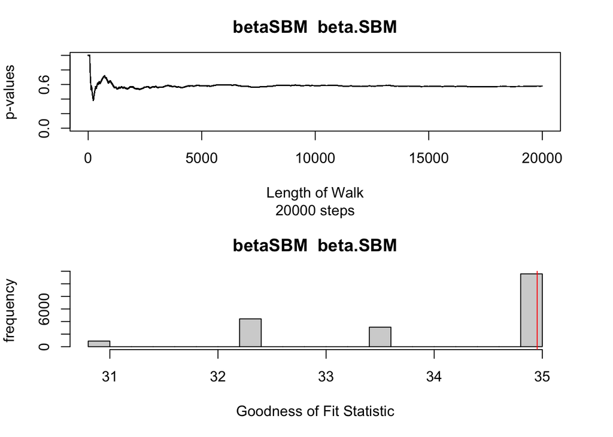

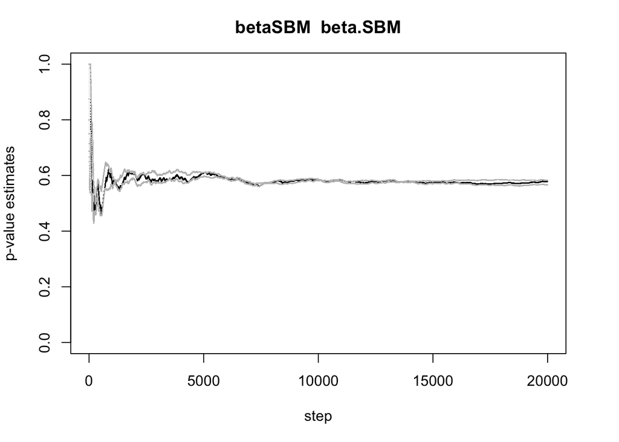

```r
test.b.SBM.no.trivial.moves = Test.Model.Fit(g, foldername=myFolderName, numSteps=steps, iterations=iters, model="beta.SBM", ignore.trivial.moves=TRUE, mleMatr=mle.b.SBM, testname="betaSBM", SBM.blocks = my.blocks)
```

```
## iteration = 1
## [1] "Estimate.p.Value.for.Testing log: Employing user-provided MLE."
## p.values[1] = 0.561051
```

```
## mean(p.values[1:1]) = 0.561051 | median(p.values[1:1]) = 0.561051 | var(p.values[1:1]) = NA
## iteration = 2
## [1] "Estimate.p.Value.for.Testing log: Employing user-provided MLE."
## p.values[2] = 0.573608
```

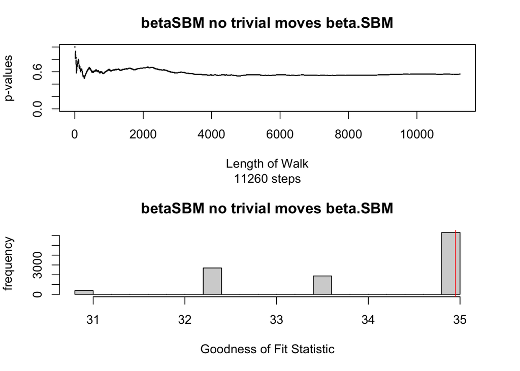

```
## mean(p.values[1:2]) = 0.567330 | median(p.values[1:2]) = 0.567330 | var(p.values[1:2]) = 0.000079
## iteration = 3
## [1] "Estimate.p.Value.for.Testing log: Employing user-provided MLE."
## p.values[3] = 0.614287
```

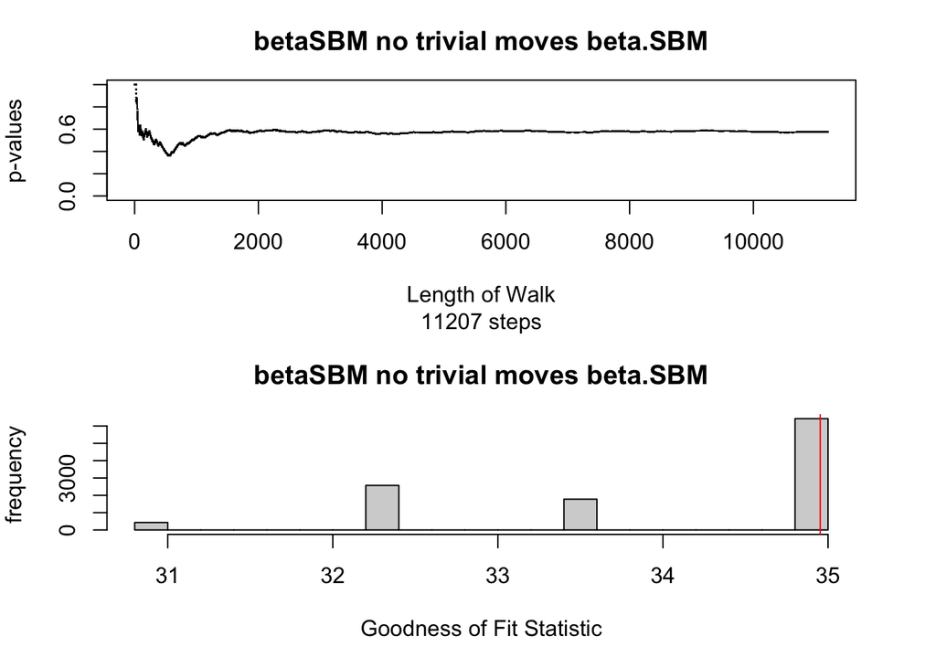

```
## mean(p.values[1:3]) = 0.582982 | median(p.values[1:3]) = 0.573608 | var(p.values[1:3]) = 0.000774
```

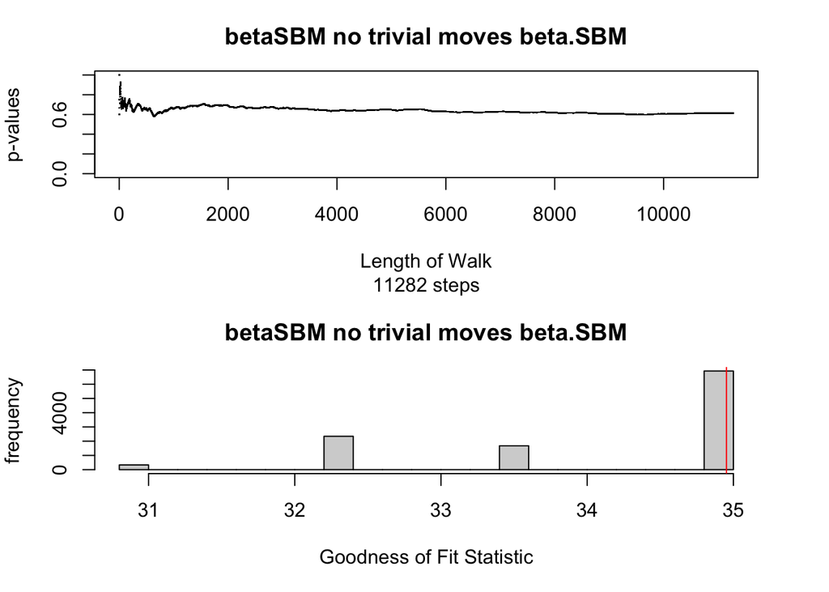

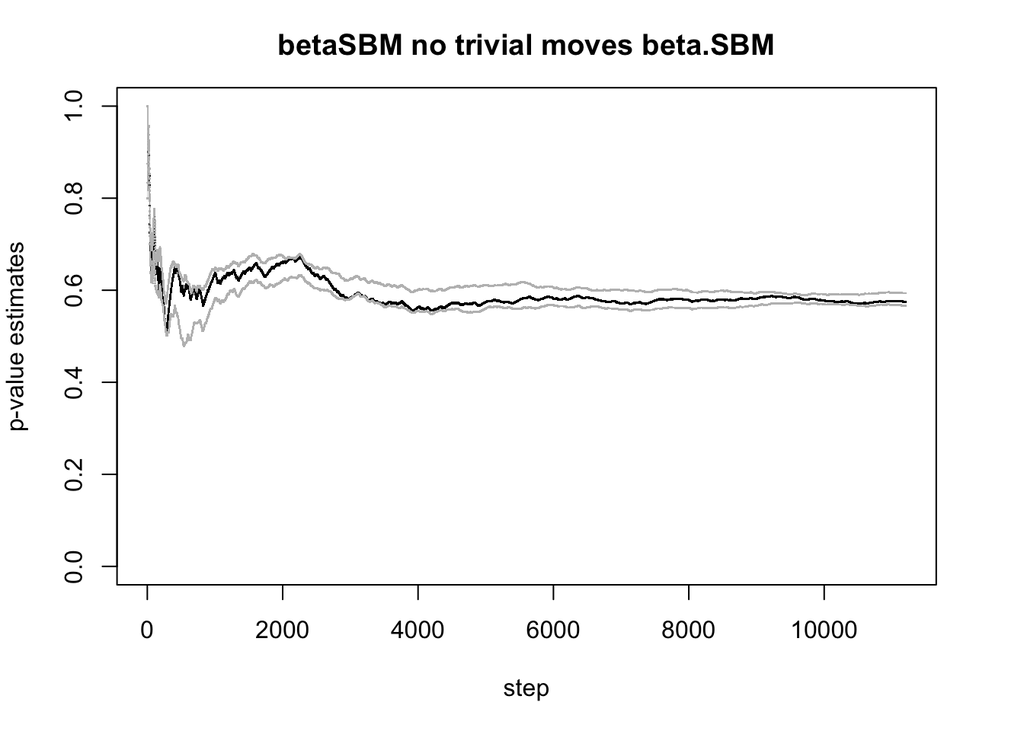

In addition the user may wish to save all of the plots from the random walk on the model fiber, as well as print all graphs visited. We do not provide output for this, for obvious space considerations.

```
Save.Walk.Plots(graph.empty(vcount(g)), g, model = "beta.SBM", steps=500, SBM.blocks=my.blocks, plot.trivial.moves=FALSE,single.file=TRUE, filename="/Users/sonjapetrovic/temp/betaSBM.simple.walk.pdf" )
enum = Enumerate.Fiber(graph.empty(vcount(g)), g, model = "beta.SBM", numsteps=500, SBM.blocks=my.blocks)
```

# Examples in the paper

Each of the examples below require the three R files that contain the implementation of the test. The files below will read the data sets, and set up the tests, and then execute them.

## Neuronal network from Section 4.2

The above R files require the following: `NeuronalNetworkBothWODirectionAndBlocksBasedonType.R`, `NeuronalNetworkDirected.R`, and `NeuronalNetworkDirectedandUndirected.R` which are setup to read the data files in proper (network) format from .csv raw data.

## Protein-protein interaction network from Section 4.3

- Testing the $p_1$ model with dyad-specific reciprocation on the protein-protein interaction network with a large number of structural zero edges: `ProteinProtein.P1dyaddependent.Zeros.Parallel.ChisqDiagnostics.R`.